# Revised Statistical Analysis: Absorption

##### Assumptions about the residuals

Can be examined visually

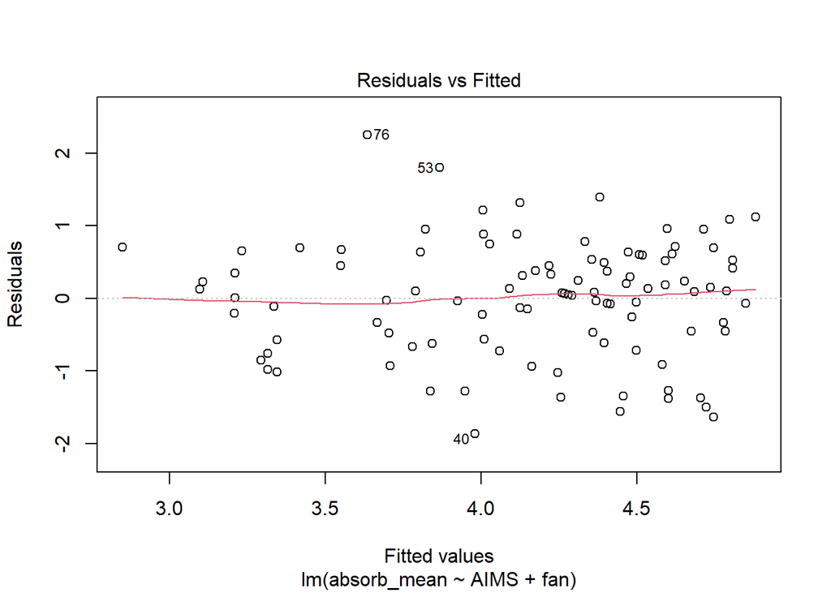

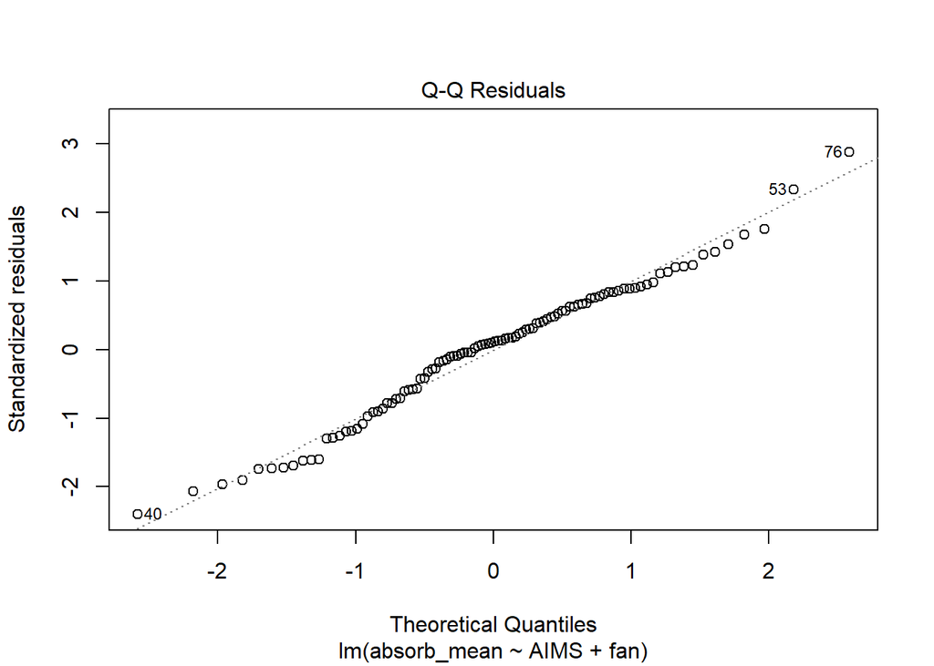

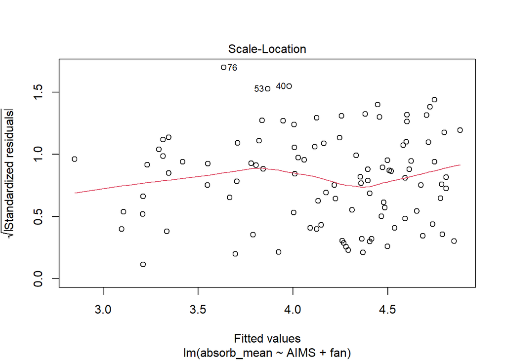

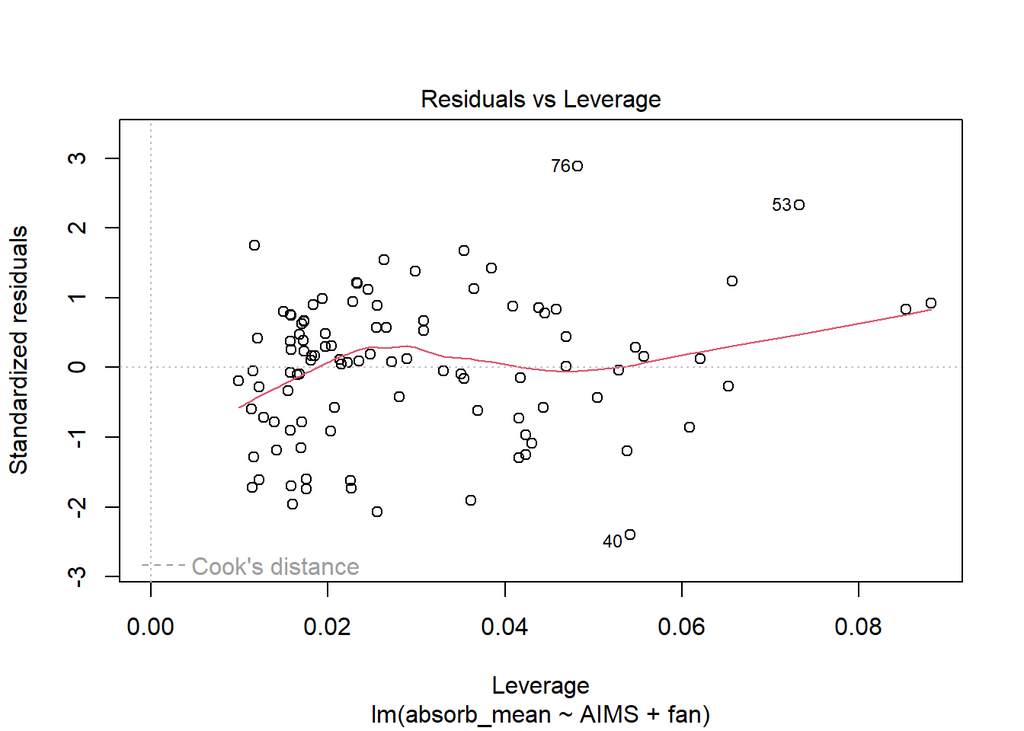

```r
plot(m1)
```

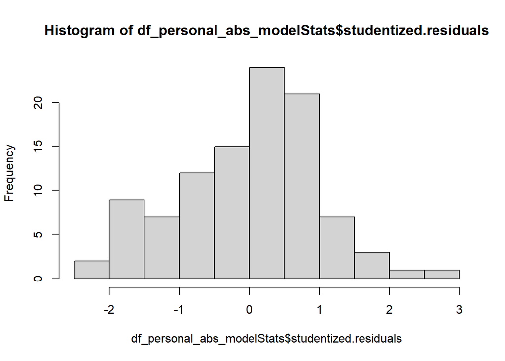

```r
# residuals vs fitted plot looks good. no evidence of heteroscedasticity or nonlinearity.
# QQplot shows little to no deviations from normality

hist(df_personal_abs_modelStats$studentized.residuals)
```

```r
# looks pretty normal
```

### Summary

The model appears to be both accurate for the sample and generalizable to the population.

The best model for explaining the influence of individual characteristics on absorption contains AIMS and fan-status as significant predictors. Together they explain 27% of the variance. The AIMS is a personality scale that measures participants’ typical absorption with music. Fan-status was an even stronger predictor of absorption than AIMS.

```r
summary(m1)
```

```
##
## Call:
## lm(formula = absorb_mean ~ AIMS + fan, data = df_aims_fan_nona)
##
## Residuals:
##      Min       1Q   Median       3Q      Max
## -1.86972 -0.54449  0.08746  0.53161  2.25316
##
## Coefficients:
##             Estimate Std. Error t value Pr(>|t|)
## (Intercept) 2.173771   0.379604   5.726  1.1e-07 ***
## AIMS        0.010339   0.003191   3.240  0.00163 **
## fan         0.159188   0.034366   4.632  1.1e-05 ***
## ---
## Signif. codes:  0 '***' 0.001 '**' 0.01 '*' 0.05 '.' 0.1 ' ' 1
##
## Residual standard error: 0.8005 on 99 degrees of freedom
## Multiple R-squared:  0.2806, Adjusted R-squared:  0.266
## F-statistic: 19.31 on 2 and 99 DF,  p-value: 8.331e-08
```

```r
# 107 observations and 5 observations deleted due to missingness (in the predictor variables rather than the absorption variable)
confint(m1, level = .95)
```

```
##                   2.5 %     97.5 %
## (Intercept) 1.420554791 2.92698799
## AIMS        0.004006816 0.01667205
## fan         0.090998592 0.22737826
```

```r
df_aims_fan_nona%>%group_by(group)%>%summarise(n())
```

```
## # A tibble: 2 × 2
##   group   `n()`
##   <fct>   <int>
## 1 Live       84
## 2 Virtual    18
```

### Visualize the regression model

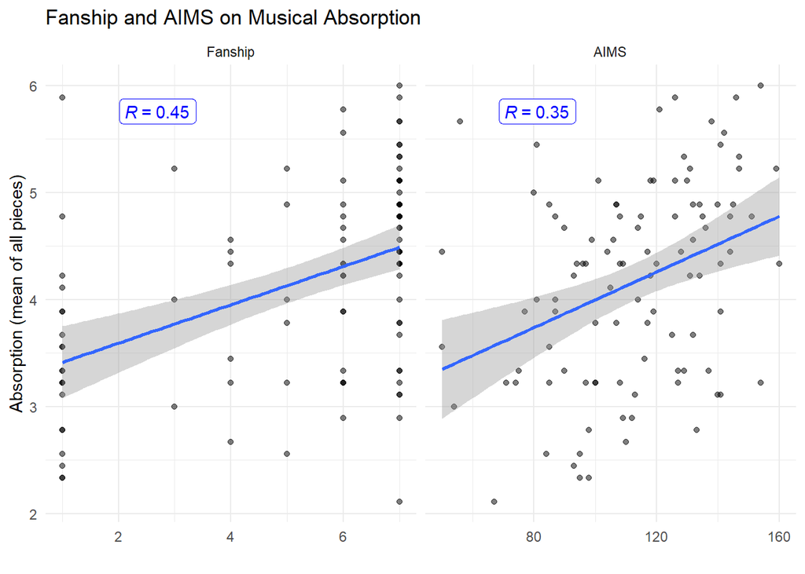

```r
df_aims_fan_nona.long<-df_aims_fan_nona%>%pivot_longer(c(fan, AIMS), names_to = "variable")
df_aims_fan_nona.long$variable<-factor(df_aims_fan_nona.long$variable, levels = c("fan", "AIMS"), labels = c("Fanship", "AIMS"))

# this vis looks best to me.
df_aims_fan_nona.long%>%
  ggplot(aes(x = value, y = absorb_mean))+
  facet_grid(cols = vars(variable), scales = "free")+
  geom_point(alpha = .5)+
  geom_smooth(method = "lm")+
  labs(title = "Fanship and AIMS on Musical Absorption", x = "", y = "Absorption (mean of all pieces)")+
  theme_minimal()+
  stat_cor(aes(label = ..r.label..), label.x.npc = .17,label.y.npc = .95, color = "blue", geom = "label")
```

```r
graphname<-paste0("../revised_plots/Fanship_aims_absorb.png")
ggsave(graphname, width = 15, height = 8, units = 'cm', dpi = 500)
graphname<-paste0("../revised_plots/Publication_Figures/Fanship_aims_absorb.jpg")
ggsave(graphname, width = 15, height = 8, units = 'cm', dpi = 500, bg = "white")
```

# 3.5.1 Absorption ~ Group + Piece

3.5 What is the influence of social context (group: Live, Livestreaming) and the piece of music (Beethoven, Schnittke, Folk) on musical absorption and mind-wandering?

```r
dat<-df.full%>%select(Pt_ID, group,contains("mus_abs"))

df.long<-dat%>%pivot_longer(!c(group, Pt_ID), #make long
                            names_to = c("piece"),
                            names_pattern ="mus_abs_(.*)",
                            values_to = "Absorption")

df.long$piece<-factor(df.long$piece, levels = c("Beethoven", "Schnittke", "Folk"))
#factor for the correct facet order

data<-df.long%>%drop_na() #408 to 368

data%>%group_by(group, piece)%>%summarize(n())
```

```
## # A tibble: 6 × 3
## # Groups:   group [2]
##   group   piece     `n()`
##   <fct>   <fct>     <int>
## 1 Live    Beethoven    88
## 2 Live    Schnittke    90
## 3 Live    Folk         89
## 4 Virtual Beethoven    38
## 5 Virtual Schnittke    32
## 6 Virtual Folk         31
```

IV1: group, IV2: piece, DV: Absorption factor score

```r
data %>%
  group_by(group, piece) %>%
  get_summary_stats(Absorption, type = "mean_sd")
```

```
## # A tibble: 6 × 6
##   group   piece     variable       n  mean    sd
##   <fct>   <fct>     <fct>      <dbl> <dbl> <dbl>
## 1 Live    Beethoven Absorption    88  4.16  1.07
## 2 Live    Schnittke Absorption    90  4.11  1.16
## 3 Live    Folk      Absorption    89  4.42  1.13
## 4 Virtual Beethoven Absorption    38  3.5   1.05
## 5 Virtual Schnittke Absorption    32  3.82  1.08
## 6 Virtual Folk      Absorption    31  4.11  1.20
```

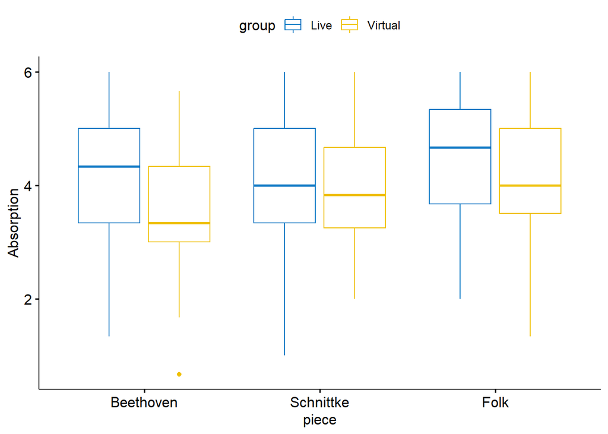

```r
bxp <- ggboxplot(
  data, x = "piece", y = "Absorption",
  color = "group", palette = "jco"
  )
bxp
```

```r
outliers<-data %>%
  group_by(group, piece) %>%
  identify_outliers(Absorption)

outliers
```

```
## # A tibble: 1 × 6
##   group   piece     Pt_ID  Absorption is.outlier is.extreme
##   <fct>   <fct>     <chr>       <dbl> <lgl>      <lgl>
## 1 Virtual Beethoven BDQ092      0.667 TRUE       FALSE
```

There were no extreme outliers and this outlier appears to be a real result and not an error of data entry.

### LME4

lme4 handles uneven sample sizes better than mixed ANOVAs

```r
baseline<-lmer(Absorption ~ 1 +(1|Pt_ID), data = data, REML = FALSE)
groupM<-lmer(Absorption ~ 1 + group + (1|Pt_ID), data = data, REML = FALSE)
anova(baseline, groupM) # sig effect group, p = .0132
```

```
## Data: data
## Models:
## baseline: Absorption ~ 1 + (1 | Pt_ID)
## groupM: Absorption ~ 1 + group + (1 | Pt_ID)
##          npar    AIC    BIC  logLik deviance Chisq Df Pr(>Chisq)
## baseline    3 1063.0 1074.7 -528.49   1057.0
## groupM      4 1058.8 1074.5 -525.42   1050.8 6.142  1     0.0132 *
## ---
## Signif. codes:  0 '***' 0.001 '**' 0.01 '*' 0.05 '.' 0.1 ' ' 1
```

```r
pieceM<-lmer(Absorption ~ 1 + piece + (1|Pt_ID), data = data, REML = FALSE)
anova(baseline, pieceM) # sig. p = .0018
```

```
## Data: data
## Models:
## baseline: Absorption ~ 1 + (1 | Pt_ID)
## pieceM: Absorption ~ 1 + piece + (1 | Pt_ID)
##          npar    AIC    BIC  logLik deviance  Chisq Df Pr(>Chisq)
## baseline    3 1063.0 1074.7 -528.49   1057.0
## pieceM      5 1054.3 1073.9 -522.16   1044.3 12.656  2   0.001786 **
## ---
## Signif. codes:  0 '***' 0.001 '**' 0.01 '*' 0.05 '.' 0.1 ' ' 1
```

```r
piece_groupM<-lmer(Absorption ~ 1 + piece + group + (1|Pt_ID), data = data, REML = FALSE)
anova(baseline, pieceM, piece_groupM) # sig effect of group even when accounting for effect of piece p =.016
```

```
## Data: data
## Models:
## baseline: Absorption ~ 1 + (1 | Pt_ID)
## pieceM: Absorption ~ 1 + piece + (1 | Pt_ID)
## piece_groupM: Absorption ~ 1 + piece + group + (1 | Pt_ID)
##              npar    AIC    BIC  logLik deviance   Chisq Df Pr(>Chisq)
## baseline        3 1063.0 1074.7 -528.49   1057.0
## pieceM          5 1054.3 1073.9 -522.16   1044.3 12.6561  2   0.001786 **
## piece_groupM    6 1050.5 1074.0 -519.26   1038.5  5.8072  1   0.015961 *
## ---
## Signif. codes:  0 '***' 0.001 '**' 0.01 '*' 0.05 '.' 0.1 ' ' 1
```

```r
piece_x_groupM<-lmer(Absorption ~ 1 + piece * group + (1|Pt_ID), data = data, REML = FALSE)
anova(baseline, pieceM, piece_groupM, piece_x_groupM) # no interaction between group and piece p = .49
```

```
## Data: data
## Models:
## baseline: Absorption ~ 1 + (1 | Pt_ID)
## pieceM: Absorption ~ 1 + piece + (1 | Pt_ID)
## piece_groupM: Absorption ~ 1 + piece + group + (1 | Pt_ID)
## piece_x_groupM: Absorption ~ 1 + piece * group + (1 | Pt_ID)
##                npar    AIC    BIC  logLik deviance   Chisq Df Pr(>Chisq)
## baseline          3 1063.0 1074.7 -528.49   1057.0
## pieceM            5 1054.3 1073.9 -522.16   1044.3 12.6561  2   0.001786 **
## piece_groupM      6 1050.5 1074.0 -519.26   1038.5  5.8072  1   0.015961 *
## piece_x_groupM    8 1053.1 1084.3 -518.54   1037.1  1.4402  2   0.486701
## ---
## Signif. codes:  0 '***' 0.001 '**' 0.01 '*' 0.05 '.' 0.1 ' ' 1
```

There were significant effects of piece and group.

Report estimates and variance with REML

```r
piece_groupM<-lmer(Absorption ~ 1 + piece + group + (1|Pt_ID), data = data, REML = FALSE)
summary(piece_groupM)
```

```
## Linear mixed model fit by maximum likelihood  ['lmerMod']
## Formula: Absorption ~ 1 + piece + group + (1 | Pt_ID)
##    Data: data
##
##      AIC      BIC   logLik deviance df.resid
##   1050.5   1074.0   -519.3   1038.5      362
##
## Scaled residuals:
##      Min       1Q   Median       3Q      Max
## -3.15907 -0.46413  0.09082  0.62191  2.01060
##
## Random effects:
##  Groups   Name        Variance Std.Dev.
##  Pt_ID    (Intercept) 0.6337   0.7961
##  Residual             0.6030   0.7766
## Number of obs: 368, groups:  Pt_ID, 135
##
## Fixed effects:
##                Estimate Std. Error t value
## (Intercept)     4.12001    0.11245  36.638
## pieceSchnittke  0.01451    0.10034   0.145
## pieceFolk       0.31785    0.10075   3.155
## groupVirtual   -0.42405    0.17411  -2.436
##
## Correlation of Fixed Effects:
##             (Intr) pcSchn picFlk
## piecSchnttk -0.450
## pieceFolk   -0.448  0.495
## groupVirtul -0.490  0.029  0.032
```

```r
piece_groupM_reml<-lmer(Absorption ~ 1 + piece + group + (1|Pt_ID), data = data, REML = TRUE)
summary(piece_groupM_reml)
```

```
## Linear mixed model fit by REML ['lmerMod']
## Formula: Absorption ~ 1 + piece + group + (1 | Pt_ID)
##    Data: data
##
## REML criterion at convergence: 1049.2
##
## Scaled residuals:
##      Min       1Q   Median       3Q      Max
## -3.14365 -0.46153  0.09313  0.61743  2.00375
##
## Random effects:
##  Groups   Name        Variance Std.Dev.
##  Pt_ID    (Intercept) 0.6448   0.8030
##  Residual             0.6082   0.7799
## Number of obs: 368, groups:  Pt_ID, 135
##
## Fixed effects:
##                Estimate Std. Error t value
## (Intercept)     4.12011    0.11321  36.393
## pieceSchnittke  0.01436    0.10077   0.142
## pieceFolk       0.31772    0.10118   3.140
## groupVirtual   -0.42403    0.17541  -2.417
##
## Correlation of Fixed Effects:
##             (Intr) pcSchn picFlk
## piecSchnttk -0.448
## pieceFolk   -0.447  0.495
## groupVirtul -0.491  0.029  0.032
```

Results are only very sligthly different between REML = FALSE and REML = TRUE.

## Post-hoc testing

```r
estimate_means(piece_groupM, at = "piece")
```

```
## Estimated Marginal Means
##
## piece     | Mean |   SE |       95% CI
## --------------------------------------
## Beethoven | 3.91 | 0.10 | [3.70, 4.11]
## Schnittke | 3.92 | 0.11 | [3.71, 4.13]
## Folk      | 4.23 | 0.11 | [4.02, 4.44]
##
## Marginal means estimated at piece
```

```r
estimate_contrasts(piece_groupM, contrast = "piece")
```

```
## Marginal Contrasts Analysis
##
## Level1    |    Level2 | Difference |         95% CI |   SE |     df |     t |     p
## -----------------------------------------------------------------------------------
## Beethoven |      Folk |      -0.32 | [-0.56, -0.07] | 0.10 | 244.30 | -3.14 | 0.006
## Beethoven | Schnittke |      -0.01 | [-0.26,  0.23] | 0.10 | 244.72 | -0.14 | 0.886
## Schnittke |      Folk |      -0.30 | [-0.55, -0.06] | 0.10 | 241.97 | -2.99 | 0.006
##
## Marginal contrasts estimated at piece
## p-value adjustment method: Holm (1979)
```

```r
estimate_means(piece_groupM, at = "group")
```

```
## Estimated Marginal Means
##
## group   | Mean |   SE |       95% CI
## ------------------------------------
## Live    | 4.23 | 0.10 | [4.04, 4.42]
## Virtual | 3.81 | 0.15 | [3.52, 4.10]
##
## Marginal means estimated at group
```

```r
estimate_contrasts(piece_groupM, contrast = "group")
```

```
## Marginal Contrasts Analysis
##
## Level1 |  Level2 | Difference |       95% CI |   SE | t(144.56) |     p
## -----------------------------------------------------------------------
## Live   | Virtual |       0.42 | [0.08, 0.77] | 0.18 |      2.42 | 0.017
##
## Marginal contrasts estimated at group
## p-value adjustment method: Holm (1979)
```

### Check assumptions

*Linearity* Because there is no obvious pattern in the residuals, it seems like there is no violation of the linearity assumption.

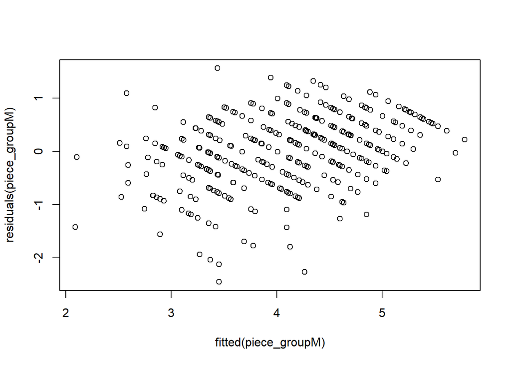

```r
plot(fitted(piece_groupM),residuals(piece_groupM))
```

*Absence of Collinearity* If two fixed effects predictors are correlated with each other, they are said to be collinear.

They can’t be correlated because they are both factors.

*Homoskedasticity* This doesn’t appear obviously heteroscedastic but it isn’t perfect either. We can check with Levene’s test for checking variance across groups

```r
leveneTest(data$Absorption, data$group, center = mean) # variance is not different across groups.
```

```
## Levene's Test for Homogeneity of Variance (center = mean)
##        Df F value Pr(>F)
## group   1  0.0172 0.8957
##       366
```

*Normality of residuals* “The normality of residuals assumption is the one that is least important. Interestingly, many people seem to think it is the most important one, but it turns  
out that linear models are relatively robust against violations of the assumptions of normality. Researchers differ with respect to how much weight they put onto  
checking this assumption. For example, Gellman and Hill (2007), a famous book on linear models and mixed models, do not even recommend diagnostics of the normality assumption (ibid. 46).”

Therefore, it may be ok to violate this assumption.

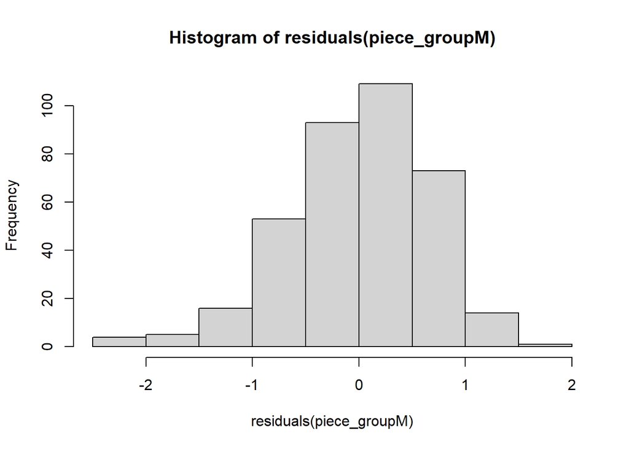

```r
hist(residuals(piece_groupM)) #  not bad. slight negative tail.
```

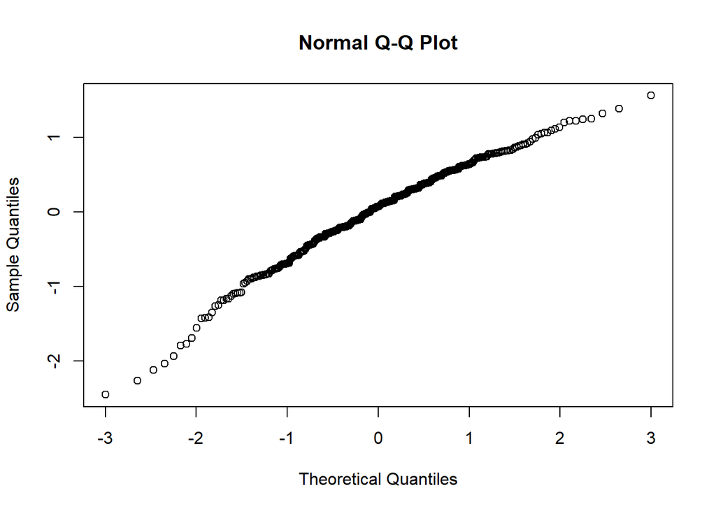

```r
qqnorm(residuals(piece_groupM)) # slight skew
```

```r
require(lattice)
```

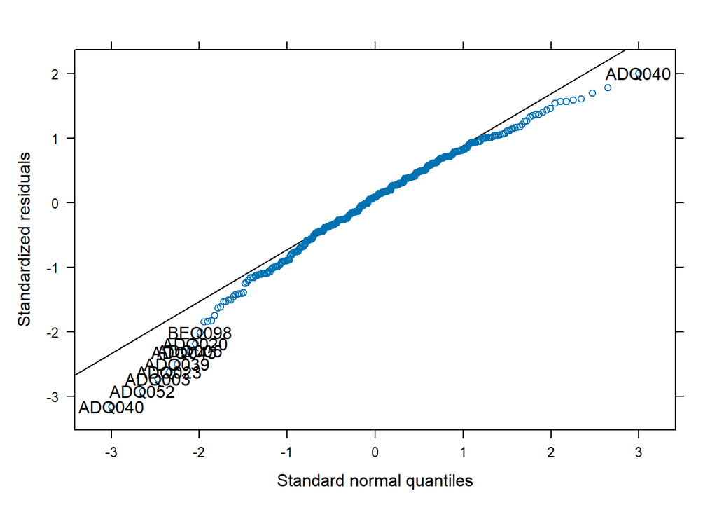

```r
qqmath(piece_groupM, id=0.05) #id: identifies values that may be exerting undue influence on the model (i.e. outliers
```

### Visualize

```r
colours_DSQ<-c("#2d769a","#b34036")

#update group label
data$group<-factor(data$group, levels = c("Live", "Virtual"), labels = c("Live", "Livestreaming"))
```

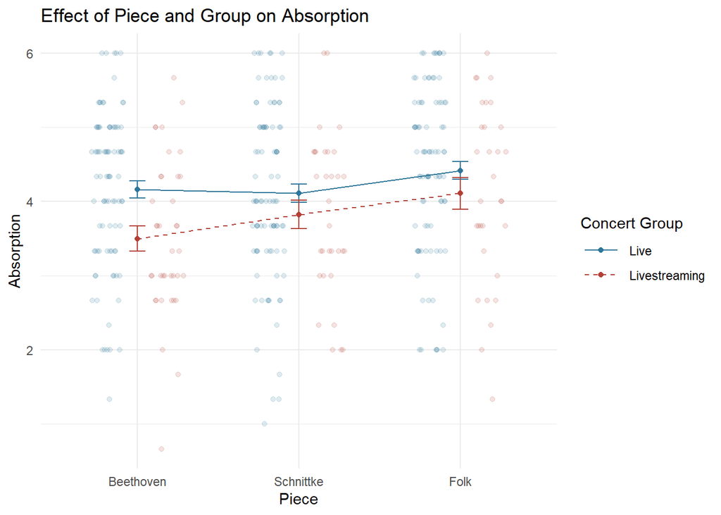

```r
plot_dat<-data%>%group_by(group, piece)%>%summarise(mean = mean(Absorption), se = sd(Absorption)/sqrt(n()))
ggplot(plot_dat, aes(x = piece))+
    geom_errorbar(aes(y = mean, color = group, ymin=mean-se, ymax=mean+se), width=.1, show.legend = FALSE)+
    geom_line(aes(y = mean, color = group, group = group, linetype = group)) +
    geom_point(aes( y = mean, color = group))+
    geom_point(data = data, aes(height = .5, width = .5, x = piece, y = Absorption, color = group), alpha = .15, position = position_jitterdodge())+
    scale_linetype_manual(values = c("solid", "dashed"))+
    scale_color_manual(values = colours_DSQ)+
    theme_minimal()+theme(legend.key.width = unit(.4, "in"))+
    labs(x = "Piece", y = "Absorption", title = "Effect of Piece and Group on Absorption", linetype = "Concert Group", color = "Concert Group")
```

```r
graphname<-paste0("../revised_plots/Publication_Figures/Absorption-piece_group_line.jpg")
ggsave(graphname, width = 17, height = 10, units = 'cm', dpi = 500, bg= "white")
```

## Check if fanship could actually be accounting for the differences more than the group.

Because there was a group difference in fanship therefore this could be a confounding variable.

```r
dat<-df.full%>%select(Pt_ID, group,contains("mus_abs"), fan)

df.long<-dat%>%pivot_longer(!c(group, Pt_ID, fan), #make long
                            names_to = c("piece"),
                            names_pattern ="mus_abs_(.*)",
                            values_to = "Absorption")

df.long$piece<-factor(df.long$piece, levels = c("Beethoven", "Schnittke", "Bach", "Folk"))
#factor for the correct facet order

data<-df.long%>%drop_na() #408 to 341

data%>%group_by(group, piece)%>%summarize(n())
```

```
## # A tibble: 6 × 3
## # Groups:   group [2]
##   group   piece     `n()`
##   <fct>   <fct>     <int>
## 1 Live    Beethoven    87
## 2 Live    Schnittke    89
## 3 Live    Folk         88
## 4 Virtual Beethoven    31
## 5 Virtual Schnittke    23
## 6 Virtual Folk         23
```

```r
# recheck the model with this new data
baseline<-lmer(Absorption ~ 1 + (1|Pt_ID), data = data, REML = FALSE)
pieceM<-lmer(Absorption ~ 1 + piece + (1|Pt_ID), data = data, REML = FALSE)
piece_groupM<-lmer(Absorption ~ 1 + piece + group + (1|Pt_ID), data = data, REML = FALSE)
piece_group_fanM<-lmer(Absorption ~ 1 + piece + group + fan + (1|Pt_ID), data = data, REML = FALSE) # sig effect of fan
piece_group_x_fanM<-lmer(Absorption ~ 1 + piece + group * fan + (1|Pt_ID), data = data, REML = FALSE) #trending
piece_x_group_fanM<-lmer(Absorption ~ 1 + piece* fan + group + (1|Pt_ID), data = data, REML = FALSE) #NS
anova(baseline, pieceM, piece_groupM, piece_group_fanM,piece_x_group_fanM)
```

```
## Data: data
## Models:
## baseline: Absorption ~ 1 + (1 | Pt_ID)
## pieceM: Absorption ~ 1 + piece + (1 | Pt_ID)
## piece_groupM: Absorption ~ 1 + piece + group + (1 | Pt_ID)
## piece_group_fanM: Absorption ~ 1 + piece + group + fan + (1 | Pt_ID)
## piece_x_group_fanM: Absorption ~ 1 + piece * fan + group + (1 | Pt_ID)
##                    npar    AIC     BIC  logLik deviance   Chisq Df Pr(>Chisq)
## baseline              3 985.92  997.42 -489.96   979.92
## pieceM                5 979.35  998.51 -484.67   969.35 10.5772  2   0.005049
## piece_groupM          6 977.41 1000.40 -482.70   965.41  3.9367  1   0.047244
## piece_group_fanM      7 954.22  981.04 -470.11   940.22 25.1918  1   5.19e-07
## piece_x_group_fanM    9 957.68  992.17 -469.84   939.68  0.5339  2   0.765723
##
## baseline
## pieceM             **
## piece_groupM       *
## piece_group_fanM   ***
## piece_x_group_fanM
## ---
## Signif. codes:  0 '***' 0.001 '**' 0.01 '*' 0.05 '.' 0.1 ' ' 1
```

```r
anova(baseline, pieceM, piece_groupM, piece_group_fanM,piece_group_x_fanM)
```

```
## Data: data
## Models:
## baseline: Absorption ~ 1 + (1 | Pt_ID)
## pieceM: Absorption ~ 1 + piece + (1 | Pt_ID)
## piece_groupM: Absorption ~ 1 + piece + group + (1 | Pt_ID)
## piece_group_fanM: Absorption ~ 1 + piece + group + fan + (1 | Pt_ID)
## piece_group_x_fanM: Absorption ~ 1 + piece + group * fan + (1 | Pt_ID)
##                    npar    AIC     BIC  logLik deviance   Chisq Df Pr(>Chisq)
## baseline              3 985.92  997.42 -489.96   979.92
## pieceM                5 979.35  998.51 -484.67   969.35 10.5772  2   0.005049
## piece_groupM          6 977.41 1000.40 -482.70   965.41  3.9367  1   0.047244
## piece_group_fanM      7 954.22  981.04 -470.11   940.22 25.1918  1   5.19e-07
## piece_group_x_fanM    8 953.28  983.94 -468.64   937.28  2.9361  1   0.086620
##
## baseline
## pieceM             **
## piece_groupM       *
## piece_group_fanM   ***
## piece_group_x_fanM .
## ---
## Signif. codes:  0 '***' 0.001 '**' 0.01 '*' 0.05 '.' 0.1 ' ' 1
```

```r
#refit with reml
piece_group_fanM_reml<-lmer(Absorption ~ 1 + piece + group + fan + (1|Pt_ID), data = data, REML = TRUE) # sig effect of fan
summary(piece_group_fanM_reml)
```

```
## Linear mixed model fit by REML ['lmerMod']
## Formula: Absorption ~ 1 + piece + group + fan + (1 | Pt_ID)
##    Data: data
##
## REML criterion at convergence: 955.7
##
## Scaled residuals:
##     Min      1Q  Median      3Q     Max
## -3.2774 -0.4755  0.0924  0.5948  1.9911
##
## Random effects:
##  Groups   Name        Variance Std.Dev.
##  Pt_ID    (Intercept) 0.4857   0.6969
##  Residual             0.6200   0.7874
## Number of obs: 341, groups:  Pt_ID, 123
##
## Fixed effects:
##                 Estimate Std. Error t value
## (Intercept)     3.152173   0.217018  14.525
## pieceSchnittke -0.004175   0.105337  -0.040
## pieceFolk       0.287114   0.105493   2.722
## groupVirtual   -0.038880   0.189301  -0.205
## fan             0.177881   0.034113   5.215
##
## Correlation of Fixed Effects:
##             (Intr) pcSchn picFlk grpVrt
## piecSchnttk -0.231
## pieceFolk   -0.225  0.492
## groupVirtul -0.508  0.039  0.038
## fan         -0.869 -0.015 -0.021  0.350
```

```r
estimate_means(piece_group_fanM, at = "piece")
```

```
## Estimated Marginal Means
##
## piece     | Mean |   SE |       95% CI
## --------------------------------------
## Beethoven | 4.04 | 0.11 | [3.83, 4.25]
## Schnittke | 4.04 | 0.11 | [3.82, 4.26]
## Folk      | 4.33 | 0.11 | [4.11, 4.55]
##
## Marginal means estimated at piece
```

```r
estimate_contrasts(piece_group_fanM, contrast = "piece")
```

```
## Marginal Contrasts Analysis
##
## Level1    |    Level2 | Difference |         95% CI |   SE |     df |     t |     p
## -----------------------------------------------------------------------------------
## Beethoven |      Folk |      -0.29 | [-0.54, -0.03] | 0.11 | 227.98 | -2.72 | 0.020
## Beethoven | Schnittke |   3.83e-03 | [-0.25,  0.26] | 0.11 | 228.77 |  0.04 | 0.971
## Schnittke |      Folk |      -0.29 | [-0.55, -0.03] | 0.11 | 225.45 | -2.74 | 0.020
##
## Marginal contrasts estimated at piece
## p-value adjustment method: Holm (1979)
```

```r
estimate_means(piece_group_fanM, at = "group")
```

```
## Estimated Marginal Means
##
## group   | Mean |   SE |       95% CI
## ------------------------------------
## Live    | 4.16 | 0.09 | [3.98, 4.33]
## Virtual | 4.12 | 0.16 | [3.80, 4.44]
##
## Marginal means estimated at group
```

```r
estimate_contrasts(piece_group_fanM, contrast = "group")
```

```
## Marginal Contrasts Analysis
##
## Level1 |  Level2 | Difference |        95% CI |   SE | t(133.77) |     p
## ------------------------------------------------------------------------
## Live   | Virtual |       0.04 | [-0.34, 0.41] | 0.19 |      0.21 | 0.838
##
## Marginal contrasts estimated at group
## p-value adjustment method: Holm (1979)
```

# 3.6 Absorption & motion (and piece and group)

What is the relation between absorption and motion?

Useful tutorial about lme and fixed and random effects provided by Jonna: https://psyteachr.github.io/stat-models-v1/linear-mixed-effects-models-with-one-random-factor.html

## 3.6.1 LME with Quantity of Motion (QoM) & Absorption

```r
dat<-df.full%>%select(Pt_ID, group,contains("mus_abs"), contains("QoM"))

df.long<-dat%>%pivot_longer(!c(group, Pt_ID), #make long
                            names_to = c("var", "piece"),
                            names_pattern ="(.*)_(.*)",
                            values_to = "response")

# remove Bach
df.long<-df.long%>%filter(! piece == "Bach")

df.wide<-df.long%>%pivot_wider(names_from = var, values_from = response)

df.wide$piece<-factor(df.wide$piece, levels = c("Beethoven", "Schnittke", "Folk"))
#factor for the correct facet order

# note df.wide is the same as data including NA
df.wide%<>%rename("Absorption" = "mus_abs")

data<-df.wide%>%drop_na() #408 to 293
```

### Remove extreme outliers

#### Absorption

```r
outliers<-data %>%
  group_by(group, piece) %>%
  identify_outliers(Absorption)

outliers # 1; None are extreme.
```

```
## # A tibble: 1 × 7
##   group   piece     Pt_ID  Absorption  mQoM is.outlier is.extreme
##   <fct>   <fct>     <chr>       <dbl> <dbl> <lgl>      <lgl>
## 1 Virtual Beethoven BDQ092      0.667 0.460 TRUE       FALSE
```

```r
extreme<-outliers%>%filter(is.extreme == TRUE)

extreme # none are extreme
```

```
## # A tibble: 0 × 7
## # ℹ 7 variables: group <fct>, piece <fct>, Pt_ID <chr>, Absorption <dbl>,
## #   mQoM <dbl>, is.outlier <lgl>, is.extreme <lgl>
```

```r
# remove specific instances that are outliers (Pt_ID and piece, because lme can handle missing data so you don't need to remove the whole participant)

# data uten outliers
data_u_outliers<-data%>% # 293 to 292 : looks good!
  group_by(group, piece) %>%
  filter(!is_outlier(Absorption))%>%
  ungroup()

# data uten extreme
data_u_extreme<-data%>% # 293 to 293 : looks good!
  group_by(group, piece) %>%
  filter(!is_extreme(Absorption))%>%
  ungroup()
```

#### QoM

```r
outliers<-data %>%
  group_by(group, piece) %>%
  identify_outliers(mQoM)

outliers # 21
```

```
## # A tibble: 21 × 7
##    group piece     Pt_ID  Absorption  mQoM is.outlier is.extreme
##    <fct> <fct>     <chr>       <dbl> <dbl> <lgl>      <lgl>
##  1 Live  Beethoven ADQ010       3.67 0.133 TRUE       FALSE
##  2 Live  Beethoven ADQ025       4.67 0.148 TRUE       FALSE
##  3 Live  Beethoven ADQ049       5    0.144 TRUE       FALSE
##  4 Live  Beethoven ADQ016       6    0.166 TRUE       FALSE
##  5 Live  Schnittke ADQ049       5.33 0.170 TRUE       FALSE
##  6 Live  Schnittke ADQ063       3.33 0.168 TRUE       FALSE
##  7 Live  Schnittke ADQ066       3.67 0.177 TRUE       FALSE
##  8 Live  Schnittke ADQ016       5    0.169 TRUE       FALSE
##  9 Live  Folk      AEQ085       2    0.427 TRUE       TRUE
## 10 Live  Folk      ADQ018       4    0.307 TRUE       TRUE
## # ℹ 11 more rows
```

```r
extreme_outliers<- outliers%>%filter(is.extreme == TRUE)

extreme_outliers # 6 instances
```

```
## # A tibble: 6 × 7
##   group   piece     Pt_ID  Absorption  mQoM is.outlier is.extreme
##   <fct>   <fct>     <chr>       <dbl> <dbl> <lgl>      <lgl>
## 1 Live    Folk      AEQ085      2     0.427 TRUE       TRUE
## 2 Live    Folk      ADQ018      4     0.307 TRUE       TRUE
## 3 Virtual Beethoven BEQ103      3.67  0.570 TRUE       TRUE
## 4 Virtual Beethoven BDQ092      0.667 0.460 TRUE       TRUE
## 5 Virtual Schnittke BEQ114      3.33  0.325 TRUE       TRUE
## 6 Virtual Folk      BEQ106      4     0.486 TRUE       TRUE
```

```r
data_u_outliers<-data_u_outliers%>% # 293 to 272
  group_by(group, piece) %>%
  filter(!is_outlier(mQoM))%>%
  ungroup()

data_u_extreme<-data_u_extreme%>% # 293 to 287 : looks good!
  group_by(group, piece) %>%
  filter(!is_extreme(mQoM))%>%
  ungroup()
```

```r
data_u_extreme%>%group_by(group, piece)%>%summarise(n())
```

```
## # A tibble: 6 × 3
## # Groups:   group [2]
##   group   piece     `n()`
##   <fct>   <fct>     <int>
## 1 Live    Beethoven    80
## 2 Live    Schnittke    77
## 3 Live    Folk         74
## 4 Virtual Beethoven    23
## 5 Virtual Schnittke    16
## 6 Virtual Folk         17
```

### Test

#### Individual effects of group, piece, mQoM

What are the individual effects of group, piece, mQoM?

This model should be built to only show the additional contribution of mQoM and its interactions with piece and group, with a random intercept and slope of participant.

```r
baseline<-lmer(Absorption ~ 1 +(1+mQoM|Pt_ID), data = data_u_extreme, REML = FALSE)
groupM<-lmer(Absorption ~ 1 + group + (1+mQoM|Pt_ID), data = data_u_extreme, REML = FALSE)
anova(baseline, groupM) # NS
```

```
## Data: data_u_extreme
## Models:
## baseline: Absorption ~ 1 + (1 + mQoM | Pt_ID)
## groupM: Absorption ~ 1 + group + (1 + mQoM | Pt_ID)
##          npar    AIC    BIC  logLik deviance  Chisq Df Pr(>Chisq)
## baseline    5 835.42 853.72 -412.71   825.42
## groupM      6 834.83 856.79 -411.42   822.83 2.5946  1     0.1072
```

```r
pieceM<-lmer(Absorption ~ 1 + piece + (1+mQoM|Pt_ID), data = data_u_extreme, REML = FALSE)
anova(baseline, pieceM) # sig p =.039
```

```
## Data: data_u_extreme
## Models:
## baseline: Absorption ~ 1 + (1 + mQoM | Pt_ID)
## pieceM: Absorption ~ 1 + piece + (1 + mQoM | Pt_ID)
##          npar    AIC    BIC  logLik deviance  Chisq Df Pr(>Chisq)
## baseline    5 835.42 853.72 -412.71   825.42
## pieceM      7 832.96 858.57 -409.48   818.96 6.4664  2    0.03943 *
## ---
## Signif. codes:  0 '***' 0.001 '**' 0.01 '*' 0.05 '.' 0.1 ' ' 1
```

```r
qomM<-lmer(Absorption ~ 1 + mQoM + (1+mQoM|Pt_ID), data = data_u_extreme, REML = FALSE)
anova(baseline, qomM) # NS
```

```
## Data: data_u_extreme
## Models:
## baseline: Absorption ~ 1 + (1 + mQoM | Pt_ID)
## qomM: Absorption ~ 1 + mQoM + (1 + mQoM | Pt_ID)
##          npar    AIC    BIC  logLik deviance  Chisq Df Pr(>Chisq)
## baseline    5 835.42 853.72 -412.71   825.42
## qomM        6 836.35 858.31 -412.17   824.35 1.0751  1     0.2998
```

#### Model fitting

```r
# Baseline model
baseline<-lmer(Absorption ~ 1 + (1+mQoM|Pt_ID), data = data_u_extreme, REML = FALSE)
pieceM<-lmer(Absorption ~ 1 + piece + (1+mQoM|Pt_ID), data = data_u_extreme, REML = FALSE)
anova(baseline, pieceM) # Sig effect of piece. p = .039
```

```
## Data: data_u_extreme
## Models:
## baseline: Absorption ~ 1 + (1 + mQoM | Pt_ID)
## pieceM: Absorption ~ 1 + piece + (1 + mQoM | Pt_ID)
##          npar    AIC    BIC  logLik deviance  Chisq Df Pr(>Chisq)
## baseline    5 835.42 853.72 -412.71   825.42
## pieceM      7 832.96 858.57 -409.48   818.96 6.4664  2    0.03943 *
## ---
## Signif. codes:  0 '***' 0.001 '**' 0.01 '*' 0.05 '.' 0.1 ' ' 1
```

```r
# effect of group
pieceM<-lmer(Absorption ~ 1 + piece + (1+mQoM|Pt_ID), data = data_u_extreme, REML = FALSE) # boundary warning
piece_group<-lmer(Absorption ~ 1 + group + piece + (1+mQoM|Pt_ID), data = data_u_extreme, REML = FALSE)
anova(pieceM, piece_group) # trending effect of group (p = .0586). but not significant with this subset of data (so few data points).
```

```
## Data: data_u_extreme
## Models:
## pieceM: Absorption ~ 1 + piece + (1 + mQoM | Pt_ID)
## piece_group: Absorption ~ 1 + group + piece + (1 + mQoM | Pt_ID)
##             npar    AIC    BIC  logLik deviance  Chisq Df Pr(>Chisq)
## pieceM         7 832.96 858.57 -409.48   818.96
## piece_group    8 831.38 860.66 -407.69   815.38 3.5767  1     0.0586 .
## ---
## Signif. codes:  0 '***' 0.001 '**' 0.01 '*' 0.05 '.' 0.1 ' ' 1
```

```r
## no random slope comparison - more sig without random slope
pieceM_nors<-lmer(Absorption ~ 1 + piece + (1|Pt_ID), data = data_u_extreme, REML = FALSE)
piece_group_nors<-lmer(Absorption ~ 1 + group + piece + (1|Pt_ID), data = data_u_extreme, REML = FALSE)
anova(pieceM_nors, piece_group_nors) # p = .023; more sig effect of group without random slope (p = .02)
```

```
## Data: data_u_extreme
## Models:
## pieceM_nors: Absorption ~ 1 + piece + (1 | Pt_ID)
## piece_group_nors: Absorption ~ 1 + group + piece + (1 | Pt_ID)
##                  npar    AIC    BIC  logLik deviance  Chisq Df Pr(>Chisq)
## pieceM_nors         5 830.73 849.03 -410.37   820.73
## piece_group_nors    6 827.53 849.49 -407.77   815.53 5.2011  1    0.02257 *
## ---
## Signif. codes:  0 '***' 0.001 '**' 0.01 '*' 0.05 '.' 0.1 ' ' 1
```

```r
# interaction group and piece: NS
piece_group<-lmer(Absorption ~ 1 + group + piece + (1+mQoM|Pt_ID), data = data_u_extreme, REML = FALSE)
pieceXgroup<-lmer(Absorption ~ 1 + group*piece + (1+mQoM|Pt_ID), data = data_u_extreme, REML = FALSE) # boundary warning and model failed to converge
```

```
## boundary (singular) fit: see help('isSingular')
```

```r
anova(piece_group, pieceXgroup) # NS-  the interaction does not add more than the main effects
```

```
## Data: data_u_extreme
## Models:
## piece_group: Absorption ~ 1 + group + piece + (1 + mQoM | Pt_ID)
## pieceXgroup: Absorption ~ 1 + group * piece + (1 + mQoM | Pt_ID)
##             npar    AIC    BIC  logLik deviance  Chisq Df Pr(>Chisq)
## piece_group    8 831.38 860.66 -407.69   815.38
## pieceXgroup   10 835.04 871.64 -407.52   815.04 0.3412  2     0.8431
```

```r
# effect of motion
pieceM<-lmer(Absorption ~ 1 + piece + (1+mQoM|Pt_ID), data = data_u_extreme, REML = FALSE)
piece_qomM<-lmer(Absorption ~ 1 + piece + mQoM + (1+mQoM|Pt_ID), data = data_u_extreme, REML = FALSE)
anova(pieceM, piece_qomM) # NS - adding QoM NS. what about interactions?
```

```
## Data: data_u_extreme
## Models:
## pieceM: Absorption ~ 1 + piece + (1 + mQoM | Pt_ID)
## piece_qomM: Absorption ~ 1 + piece + mQoM + (1 + mQoM | Pt_ID)
##            npar    AIC    BIC  logLik deviance  Chisq Df Pr(>Chisq)
## pieceM        7 832.96 858.57 -409.48   818.96
## piece_qomM    8 834.95 864.23 -409.48   818.95 0.0071  1      0.933
```

```r
# interaction piece and motion
piece_x_qomM<-lmer(Absorption ~ 1 + piece*mQoM + (1+mQoM|Pt_ID), data = data_u_extreme, REML = FALSE)
```

```
## boundary (singular) fit: see help('isSingular')
```

```r
anova(piece_qomM, piece_x_qomM) # NS - adding QoM x piece interaction NS.
```

```
## Data: data_u_extreme
## Models:
## piece_qomM: Absorption ~ 1 + piece + mQoM + (1 + mQoM | Pt_ID)
## piece_x_qomM: Absorption ~ 1 + piece * mQoM + (1 + mQoM | Pt_ID)
##              npar    AIC    BIC  logLik deviance  Chisq Df Pr(>Chisq)
## piece_qomM      8 834.95 864.23 -409.48   818.95
## piece_x_qomM   10 836.58 873.17 -408.29   816.58 2.3732  2     0.3053
```

```r
# main effect piece and interaction between group and motion
piece_group<-lmer(Absorption ~ 1 + group + piece + (1+mQoM|Pt_ID), data = data_u_extreme, REML = FALSE)
group_piece_qomM<-lmer(Absorption ~ 1 + group + piece + mQoM + (1+mQoM|Pt_ID), data = data_u_extreme, REML = FALSE) # the effect of
anova(piece_group,group_piece_qomM) # adding qom is not sig therefore I am not sure I am allowed to add interactions?
```

```
## Data: data_u_extreme
## Models:
## piece_group: Absorption ~ 1 + group + piece + (1 + mQoM | Pt_ID)
## group_piece_qomM: Absorption ~ 1 + group + piece + mQoM + (1 + mQoM | Pt_ID)
##                  npar    AIC    BIC  logLik deviance  Chisq Df Pr(>Chisq)
## piece_group         8 831.38 860.66 -407.69   815.38
## group_piece_qomM    9 833.35 866.29 -407.68   815.35 0.0318  1     0.8586
```

```r
piece_group_x_qomM<-lmer(Absorption ~ 1 + piece + group*mQoM + (1+mQoM|Pt_ID), data = data_u_extreme, REML = FALSE)
anova(group_piece_qomM, piece_group_x_qomM) # Significant: there is added benefit of adding the interaction with qom and group.  # RESULT REPORTED IN MS
```

```
## Data: data_u_extreme
## Models:
## group_piece_qomM: Absorption ~ 1 + group + piece + mQoM + (1 + mQoM | Pt_ID)
## piece_group_x_qomM: Absorption ~ 1 + piece + group * mQoM + (1 + mQoM | Pt_ID)
##                    npar    AIC    BIC  logLik deviance  Chisq Df Pr(>Chisq)
## group_piece_qomM      9 833.35 866.29 -407.68   815.35
## piece_group_x_qomM   10 829.14 865.73 -404.57   809.14 6.2134  1    0.01268 *
## ---
## Signif. codes:  0 '***' 0.001 '**' 0.01 '*' 0.05 '.' 0.1 ' ' 1
```

```r
anova(pieceM, piece_group_x_qomM) # and this is also true even when it is compared against the simpler piece only model as well.
```

```
## Data: data_u_extreme
## Models:
## pieceM: Absorption ~ 1 + piece + (1 + mQoM | Pt_ID)
## piece_group_x_qomM: Absorption ~ 1 + piece + group * mQoM + (1 + mQoM | Pt_ID)
##                    npar    AIC    BIC  logLik deviance  Chisq Df Pr(>Chisq)
## pieceM                7 832.96 858.57 -409.48   818.96
## piece_group_x_qomM   10 829.14 865.73 -404.57   809.14 9.8219  3    0.02014 *
## ---
## Signif. codes:  0 '***' 0.001 '**' 0.01 '*' 0.05 '.' 0.1 ' ' 1
```

```r
group_piece_x_qomM<-lmer(Absorption ~ 1 + group+piece*mQoM + (1+mQoM|Pt_ID), data = data_u_extreme, REML = FALSE)  # boundary warning
```

```
## boundary (singular) fit: see help('isSingular')
```

```r
anova(group_piece_qomM, group_piece_x_qomM)
```

```
## Data: data_u_extreme
## Models:
## group_piece_qomM: Absorption ~ 1 + group + piece + mQoM + (1 + mQoM | Pt_ID)
## group_piece_x_qomM: Absorption ~ 1 + group + piece * mQoM + (1 + mQoM | Pt_ID)
##                    npar    AIC    BIC  logLik deviance Chisq Df Pr(>Chisq)
## group_piece_qomM      9 833.35 866.29 -407.68   815.35
## group_piece_x_qomM   11 834.89 875.14 -406.44   812.89 2.462  2      0.292
```

```r
# other models
piece_x_group_group_x_qomM<-lmer(Absorption ~ 1 + piece*group + group*mQoM + (1+mQoM|Pt_ID), data = data_u_extreme, REML = FALSE)
anova(piece_group_x_qomM, piece_x_group_group_x_qomM) # ns - no benefit of adding interaction of piece and group
```

```
## Data: data_u_extreme
## Models:
## piece_group_x_qomM: Absorption ~ 1 + piece + group * mQoM + (1 + mQoM | Pt_ID)
## piece_x_group_group_x_qomM: Absorption ~ 1 + piece * group + group * mQoM + (1 + mQoM | Pt_ID)
##                            npar    AIC    BIC  logLik deviance  Chisq Df
## piece_group_x_qomM           10 829.14 865.73 -404.57   809.14
## piece_x_group_group_x_qomM   12 831.53 875.44 -403.76   807.53 1.6088  2
##                            Pr(>Chisq)
## piece_group_x_qomM
## piece_x_group_group_x_qomM     0.4474
```

```r
# no sig 3-way
qomM_x_piece_x_group<-lmer(Absorption ~ 1 + mQoM*group*piece + (1+mQoM|Pt_ID), data = data_u_extreme, REML = FALSE)
anova(piece_group_x_qomM, qomM_x_piece_x_group) # NS - no 3-way interaction
```

```
## Data: data_u_extreme
## Models:
## piece_group_x_qomM: Absorption ~ 1 + piece + group * mQoM + (1 + mQoM | Pt_ID)
## qomM_x_piece_x_group: Absorption ~ 1 + mQoM * group * piece + (1 + mQoM | Pt_ID)
##                      npar    AIC    BIC  logLik deviance  Chisq Df Pr(>Chisq)
## piece_group_x_qomM     10 829.14 865.73 -404.57   809.14
## qomM_x_piece_x_group   16 835.99 894.55 -402.00   803.99 5.1421  6     0.5257
```

```r
anova(baseline, pieceM,piece_group,group_piece_qomM, piece_group_x_qomM) # sig
```

```
## Data: data_u_extreme
## Models:
## baseline: Absorption ~ 1 + (1 + mQoM | Pt_ID)
## pieceM: Absorption ~ 1 + piece + (1 + mQoM | Pt_ID)
## piece_group: Absorption ~ 1 + group + piece + (1 + mQoM | Pt_ID)
## group_piece_qomM: Absorption ~ 1 + group + piece + mQoM + (1 + mQoM | Pt_ID)
## piece_group_x_qomM: Absorption ~ 1 + piece + group * mQoM + (1 + mQoM | Pt_ID)
##                    npar    AIC    BIC  logLik deviance  Chisq Df Pr(>Chisq)
## baseline              5 835.42 853.72 -412.71   825.42
## pieceM                7 832.96 858.57 -409.48   818.96 6.4664  2    0.03943 *
## piece_group           8 831.38 860.66 -407.69   815.38 3.5767  1    0.05860 .
## group_piece_qomM      9 833.35 866.29 -407.68   815.35 0.0318  1    0.85857
## piece_group_x_qomM   10 829.14 865.73 -404.57   809.14 6.2134  1    0.01268 *
## ---
## Signif. codes:  0 '***' 0.001 '**' 0.01 '*' 0.05 '.' 0.1 ' ' 1
```